# Análisis_datos_trabajo

## **Carga del dataset y exploración inicial**

```python
import pandas as pd
import numpy as np

df = pd.read_csv("final_dataset.csv")

df.head()
```

|  | country | year | total_flights | gdp |
| --- | --- | --- | --- | --- |
| 0 | Albania | 2016 | 22319 | 1.198867e+10 |
| 1 | Albania | 2017 | 24559 | 1.325827e+10 |
| 2 | Albania | 2018 | 25515 | 1.537951e+10 |
| 3 | Albania | 2019 | 28500 | 1.558511e+10 |
| 4 | Albania | 2020 | 15288 | 1.524146e+10 |

```python
df.info()
```

```
<class 'pandas.core.frame.DataFrame'>
RangeIndex: 351 entries, 0 to 350
Data columns (total 4 columns):
 #   Column         Non-Null Count  Dtype
---  ------         --------------  -----
 0   country        351 non-null    object
 1   year           351 non-null    int64
 2   total_flights  351 non-null    int64
 3   gdp            351 non-null    float64
dtypes: float64(1), int64(2), object(1)
memory usage: 11.1+ KB
```

```python
df.describe()
```

|  | year | total_flights | gdp |
| --- | --- | --- | --- |
| count | 351.000000 | 3.510000e+02 | 3.510000e+02 |
| mean | 2020.000000 | 3.592765e+05 | 5.620153e+11 |
| std | 2.585675 | 5.390062e+05 | 9.255300e+11 |
| min | 2016.000000 | 5.383000e+03 | 4.357469e+09 |
| 25% | 2018.000000 | 3.706200e+04 | 3.378468e+10 |
| 50% | 2020.000000 | 1.079070e+05 | 2.073056e+11 |
| 75% | 2022.000000 | 4.322120e+05 | 5.770311e+11 |
| max | 2024.000000 | 2.283157e+06 | 4.685593e+12 |

El dataset es una tabla país–año con 351 observaciones (países repetidos en distintos años). Contiene el número total de vuelos (total_flights) y el PIB (gdp) por país y año. No presenta valores faltantes y las variables están en formatos numéricos adecuados para el análisis.

### *¿Cuántos países? ¿Cuántos años por país?*

```python
n_countries = df["country"].nunique()
years = sorted(df["year"].astype(int).unique())
n_years = df["year"].nunique()

print(f"Número de países: {n_countries}")
print(f"Periodo temporal analizado: {min(years)}–{max(years)}")
print(f"Número de años únicos: {n_years}")
```

```
Número de países: 39
Periodo temporal analizado: 2016–2024
Número de años únicos: 9
```

El conjunto de datos analizado incluye información de 39 países a lo largo de un periodo de 9 años (2016–2024), configurando una estructura de datos tipo panel país–año. Todas las variables se encuentran completas y correctamente tipificadas, lo que permite proceder directamente al análisis descriptivo y estadístico.

## **Análisis descriptivo**

### *Evolución anual de vuelos y GDP*

```python
by_year = df.groupby("year")[["total_flights","gdp"]].agg(["mean","median","sum"])
by_year
```

| year | total_flights mean | total_flights median | total_flights sum | gdp mean | gdp median | gdp sum |
| --- | --- | --- | --- | --- | --- | --- |
| 2016 | 389266.205128 | 111086.0 | 15181382 | 4.806399e+11 | 1.852908e+11 | 1.874496e+13 |
| 2017 | 402847.307692 | 120163.0 | 15711045 | 5.041650e+11 | 2.003811e+11 | 1.966244e+13 |
| 2018 | 425260.769231 | 127414.0 | 16585170 | 5.408084e+11 | 2.132989e+11 | 2.109153e+13 |
| 2019 | 428433.666667 | 129019.0 | 16708913 | 5.318401e+11 | 2.073056e+11 | 2.074176e+13 |
| 2020 | 185788.871795 | 56656.0 | 7245766 | 5.184597e+11 | 1.913630e+11 | 2.021993e+13 |
| 2021 | 230837.871795 | 71075.0 | 9002677 | 5.903209e+11 | 2.183038e+11 | 2.302251e+13 |
| 2022 | 360044.128205 | 107907.0 | 14041721 | 5.832136e+11 | 2.179902e+11 | 2.274533e+13 |
| 2023 | 395291.769231 | 117789.0 | 15416379 | 6.365679e+11 | 2.429462e+11 | 2.482615e+13 |
| 2024 | 415718.179487 | 126030.0 | 16213009 | 6.721219e+11 | 2.562384e+11 | 2.621275e+13 |

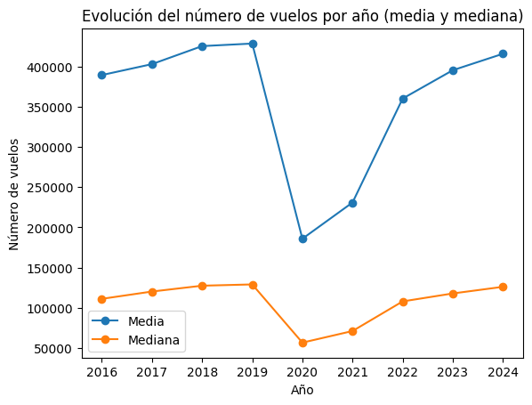

```python
plt.figure()
plt.plot(
    by_year.index,
    by_year[("total_flights", "mean")],
    marker="o",
    label="Media"
)

plt.plot(
    by_year.index,
    by_year[("total_flights", "median")],
    marker="o",
    label="Mediana"
)

plt.xlabel("Año")
plt.ylabel("Número de vuelos")
plt.title("Evolución del número de vuelos por año (media y mediana)")
plt.legend()
plt.show()
```

El análisis temporal por año permite identificar dinámicas diferenciadas a lo largo del periodo 2016–2024. En los años previos a 2020 se observa una tendencia creciente en el número de vuelos, que alcanza su máximo en 2019. En 2020 se produce una caída abrupta del tráfico aéreo, con una reducción significativa tanto de la media como del total agregado de vuelos, coherente con el impacto de la pandemia de COVID-19 sobre el transporte aéreo internacional. A partir de 2021 se aprecia una recuperación progresiva, de modo que en los años más recientes los niveles de vuelos se aproximan nuevamente a los valores previos a la pandemia.

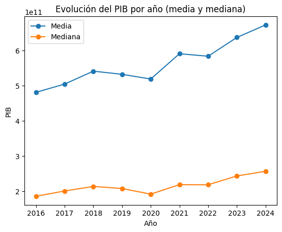

```python
plt.figure()
plt.plot(
    by_year.index,
    by_year[("gdp", "mean")],
    marker="o",
    label="Media"
)

plt.plot(
    by_year.index,
    by_year[("gdp", "median")],
    marker="o",
    label="Mediana"
)

plt.xlabel("Año")
plt.ylabel("PIB")
plt.title("Evolución del PIB por año (media y mediana)")
plt.legend()
plt.show()
```

### *Distribución de los datos*

```python
df["total_flights"] = df["total_flights"].astype(int)

desc = df[["total_flights", "gdp"]].agg(
    ["mean", "median", "std", "min", "max"]
)

desc.style.format({
    "total_flights": "{:,.0f}",
    "gdp": "{:.2e}"
})
```

|  | total_flights | gdp |
| --- | --- | --- |
| mean | 359,277 | 5.62e+11 |
| median | 107,907 | 2.07e+11 |
| std | 539,006 | 9.26e+11 |
| min | 5,383 | 4.36e+09 |
| max | 2,283,157 | 4.69e+12 |

```python
df[["total_flights","gdp"]].quantile([0.05, 0.25, 0.5, 0.75, 0.95])
```

|  | total_flights | gdp |
| --- | --- | --- |
| 0.05 | 13243.0 | 1.186273e+10 |
| 0.25 | 37062.0 | 3.378468e+10 |
| 0.50 | 107907.0 | 2.073056e+11 |
| 0.75 | 432212.0 | 5.770311e+11 |
| 0.95 | 1855572.0 | 2.835249e+12 |

Los estadísticos descriptivos realizados hasta ahora revelan una elevada heterogeneidad entre países tanto en el número de vuelos como en el PIB. En ambas variables, la media es sustancialmente superior a la mediana, lo que evidencia distribuciones fuertemente asimétricas a la derecha y la presencia de valores extremos correspondientes a economías y mercados aéreos de gran tamaño.

En el caso del número total de vuelos, la mediana se sitúa en torno a 108 mil vuelos, mientras que el 25% de las observaciones no supera los 37 mil vuelos anuales. Sin embargo, el 5% superior alcanza valores por encima de 1,8 millones de vuelos, lo que pone de manifiesto una fuerte concentración del tráfico aéreo.

De forma análoga, el PIB presenta una dispersión muy elevada, con una mediana de aproximadamente 2,1·10¹¹ y un percentil 95 superior a 2,8·10¹². Este patrón justifica el uso de transformaciones logarítmicas en los análisis posteriores con el objetivo de facilitar la interpretación y reducir el impacto de los valores extremos.

#### *Histogramas en escala original*

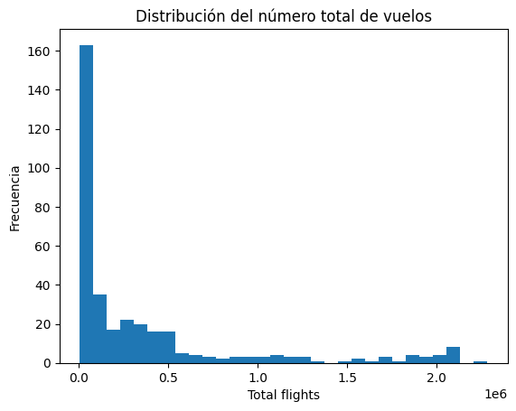

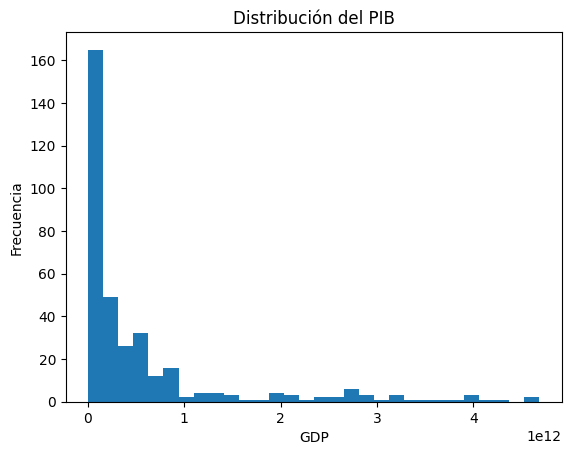

```python
import matplotlib.pyplot as plt
import numpy as np

plt.hist(df["total_flights"], bins=30)
plt.xlabel("Total flights")
plt.ylabel("Frecuencia")
plt.title("Distribución del número total de vuelos")
plt.show()

plt.hist(df["gdp"], bins=30)
plt.xlabel("GDP")
plt.ylabel("Frecuencia")
plt.title("Distribución del PIB")
plt.show()
```

Tal y como se observa en los histogramas, ambas variables presentan una fuerte concentración de observaciones en valores bajos y colas largas hacia la derecha, lo que confirma visualmente la elevada asimetría y la presencia de valores extremos descritas en los estadísticos descriptivos.

Dada la elevada asimetría y la presencia de valores extremos en ambas variables, así como las importantes diferencias de escala entre países, se aplican transformaciones logarítmicas al número de vuelos y al PIB en los análisis posteriores. Esta transformación permite reducir la influencia de los outliers, mejorar la interpretación estadística y modelizar relaciones en términos relativos.

#### *Histogramas en escala logaritmica*

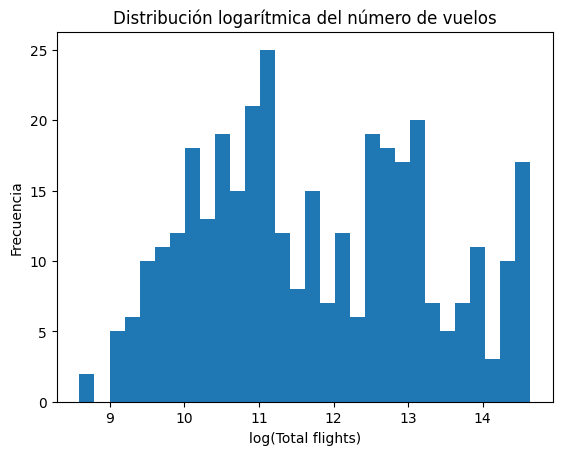

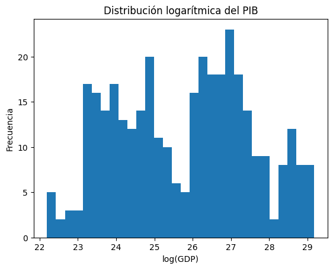

```python
import numpy as np
import matplotlib.pyplot as plt

df_log = df.copy()

df_log["total_flights"] = np.log(df_log["total_flights"])
df_log["gdp"] = np.log(df_log["gdp"])

plt.hist(df_log["total_flights"], bins=30)
plt.xlabel("log(Total flights)")
plt.ylabel("Frecuencia")
plt.title("Distribución logarítmica del número de vuelos")
plt.show()

plt.hist(df_log["gdp"], bins=30)
plt.xlabel("log(GDP)")
plt.ylabel("Frecuencia")
plt.title("Distribución logarítmica del PIB")
plt.show()
```

Tras aplicar la transformación logarítmica, ambas distribuciones se aproximan a una forma más simétrica, reduciendo la influencia de los valores extremos y facilitando la comparación entre países.

## **Análisis de la relación entre el número de vuelos y el PIB**

#### *Scatter plot Vuelos vs PIB con la escala original*

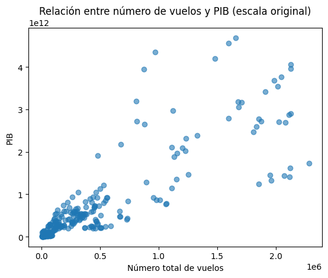

```python
import matplotlib.pyplot as plt

plt.figure()
plt.scatter(df["total_flights"], df["gdp"], alpha=0.6)
plt.xlabel("Número total de vuelos")
plt.ylabel("PIB")
plt.title("Relación entre número de vuelos y PIB (escala original)")
plt.show()
```

La gráfica muestra la relación entre el número total de vuelos y el PIB en escala original. Aunque se aprecia una asociación positiva entre ambas variables, la fuerte concentración de observaciones en valores bajos y la presencia de países con valores extremadamente elevados dificultan la identificación de un patrón claro. Este comportamiento pone de manifiesto la elevada heterogeneidad entre países y justifica el uso de transformaciones logarítmicas para analizar la relación de forma más adecuada.

#### *Scatter plot Vuelos vs PIB con la escala logarítmica*

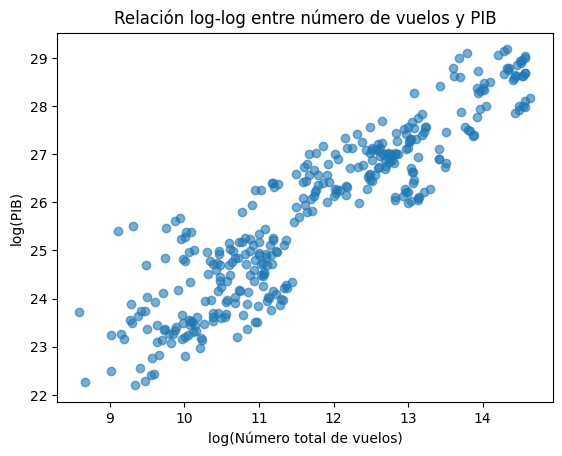

```python
plt.figure()
plt.scatter(df_log["total_flights"], df_log["gdp"], alpha=0.6)
plt.xlabel("log(Número total de vuelos)")
plt.ylabel("log(PIB)")
plt.title("Relación log-log entre número de vuelos y PIB")
plt.show()
```

Esta figura muestra la relación entre el número de vuelos y el PIB en escala logarítmica. A diferencia de la escala original, la transformación logarítmica permite observar una relación aproximadamente lineal entre ambas variables, lo que sugiere una asociación positiva de tipo multiplicativo. Esta representación reduce la influencia de los valores extremos y facilita la interpretación en términos relativos, siendo adecuada para el análisis estadístico posterior.

#### *Correlación y contraste de hipótesis*

Una vez analizada la distribución de las variables y explorada visualmente la relación entre el número de vuelos y el PIB mediante representaciones gráficas, en este apartado se procede a evaluar dicha relación de forma cuantitativa. Para ello, se emplean técnicas estadísticas basadas en la escala logarítmica, con el objetivo de reducir la influencia de los valores extremos y facilitar la interpretación en términos relativos. En particular, se calcula el coeficiente de correlación de Pearson y se estima un modelo de regresión lineal en logaritmos, lo que permite analizar la intensidad, significación y naturaleza de la asociación entre el tráfico aéreo y la actividad económica.

Hipótesis del contraste:

- H₀: no hay correlación lineal entre log(vuelos) y log(PIB) (r = 0)
- H₁: sí hay correlación lineal (r ≠ 0) (o positiva, si la planteáis unilateral)

```python
from scipy.stats import pearsonr

r, p_value = pearsonr(df_log["total_flights"], df_log["gdp"])
print("r =", r)
print("p-value =", p_value)
```

```
r = 0.9150910679331582
p-value = 1.0302253343671463e-139
```

El coeficiente de correlación de Pearson entre el logaritmo del número de vuelos y el logaritmo del PIB es r = 0,915, lo que indica una relación lineal positiva muy fuerte entre ambas variables. Este valor cercano a 1 sugiere que, en términos relativos, los países con mayor tráfico aéreo tienden a presentar niveles más elevados de PIB.

El valor p asociado al contraste es extremadamente reducido (p-value ≈ 1,0·10⁻¹³⁹), muy inferior a cualquier nivel de significación habitual (α = 0,05 o α = 0,01). En consecuencia, se rechaza la hipótesis nula de ausencia de correlación lineal y se acepta la hipótesis alternativa, concluyendo que existe evidencia estadística muy sólida de una relación lineal significativa entre el número de vuelos y el PIB en escala logarítmica.

#### *Regresión log-log: vuelos y PIB*

```python
import statsmodels.api as sm

X = sm.add_constant(df_log["total_flights"])
y = df_log["gdp"]

model = sm.OLS(y, X).fit()
model.summary()
```

OLS Regression Results

| Dep. Variable: | gdp | R-squared: | 0.837 |
| --- | --- | --- | --- |
| Model: | OLS | Adj. R-squared: | 0.837 |
| Method: | Least Squares | F-statistic: | 1797. |
| Date: | Fri, 16 Jan 2026 | Prob (F-statistic): | 1.03e-139 |
| Time: | 20:49:43 | Log-Likelihood: | -374.95 |
| No. Observations: | 351 | AIC: | 753.9 |
| Df Residuals: | 349 | BIC: | 761.6 |
| Df Model: | 1 |  |  |
| Covariance Type: | nonrobust |  |  |

|  | coef | std err | t | P>\|t\| | [0.025 | 0.975] |
| --- | --- | --- | --- | --- | --- | --- |
| const | 13.3963 | 0.295 | 45.471 | 0.000 | 12.817 | 13.976 |
| total_flights | 1.0548 | 0.025 | 42.394 | 0.000 | 1.006 | 1.104 |

| Omnibus: | 2.691 | Durbin-Watson: | 0.440 |
| --- | --- | --- | --- |
| Prob(Omnibus): | 0.260 | Jarque-Bera (JB): | 2.657 |
| Skew: | 0.212 | Prob(JB): | 0.265 |
| Kurtosis: | 2.964 | Cond. No. | 93.2 |

Notes:  
[1] Standard Errors assume that the covariance matrix of the errors is correctly specified.

Los resultados de la regresión logarítmica indican que el número de vuelos presenta un efecto positivo y estadísticamente significativo sobre el PIB. En concreto, el coeficiente estimado sugiere que un aumento del 1% en el número de vuelos se asocia, en promedio, con un incremento aproximado del 1,05% en el PIB. El elevado valor del coeficiente de determinación (R² = 0,837) indica que el tráfico aéreo explica una proporción sustancial de la variabilidad del PIB entre países y años. No obstante, estos resultados deben interpretarse como una asociación estadística y no como una relación causal, dado que el modelo no controla por otros factores económicos relevantes.

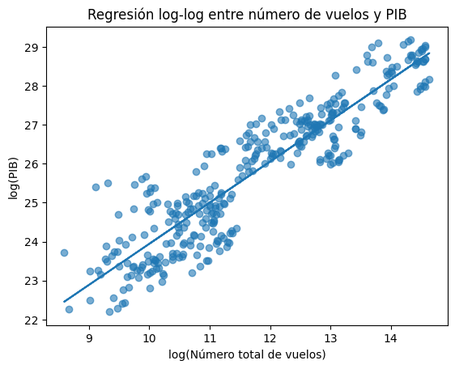

```python
import matplotlib.pyplot as plt

plt.figure()
plt.scatter(df_log["total_flights"], df_log["gdp"], alpha=0.6)
plt.plot(df_log["total_flights"], model.predict(X))
plt.xlabel("log(Número total de vuelos)")
plt.ylabel("log(PIB)")
plt.title("Regresión log-log entre número de vuelos y PIB")
plt.show()
```

La gráfica anterior muestra la regresión log-log entre el número de vuelos y el PIB. La alineación de las observaciones en torno a la recta estimada indica una relación lineal positiva y robusta entre ambas variables en escala logarítmica. La pendiente estimada refleja una elasticidad del PIB respecto al número de vuelos ligeramente superior a la unidad, lo que sugiere que incrementos relativos en el tráfico aéreo se asocian con aumentos proporcionales del nivel de actividad económica. No obstante, la dispersión observada alrededor de la recta pone de manifiesto la influencia de otros factores no incluidos en el modelo.

# **Conclusiones del análisis**

El presente trabajo analiza la relación entre el número de vuelos y el Producto Interior Bruto (PIB) en un conjunto de 39 países a lo largo del periodo 2016–2024, utilizando un panel de datos país–año construido a partir de fuentes armonizadas mediante un proceso previo de extracción, transformación y carga (ETL). El objetivo principal es evaluar si existe una asociación estadísticamente significativa entre el tráfico aéreo y el nivel de actividad económica, así como caracterizar la naturaleza de dicha relación.

El análisis exploratorio mediante gráficos de dispersión sugiere una relación positiva entre el número de vuelos y el PIB, aunque en escala original esta relación se ve distorsionada por la presencia de outliers. Por este motivo, se aplican transformaciones logarítmicas a ambas variables, lo que permite observar una relación aproximadamente lineal y facilita la interpretación en términos relativos.

En escala logarítmica, el coeficiente de correlación de Pearson entre el número de vuelos y el PIB es elevado (r = 0,915) y altamente significativo desde el punto de vista estadístico, lo que indica una asociación lineal positiva muy fuerte entre ambas variables. Este resultado se confirma mediante la estimación de un modelo de regresión lineal log-log, cuyos resultados muestran que un aumento del 1% en el número de vuelos se asocia, en promedio, con un incremento aproximado del 1,05% en el PIB. El modelo presenta un elevado poder explicativo (R² = 0,837), lo que sugiere que el tráfico aéreo explica una proporción sustancial de la variabilidad del PIB entre países y años.

En conjunto, los resultados ponen de manifiesto la existencia de una relación estadísticamente robusta y económicamente relevante entre el tráfico aéreo y la actividad económica. No obstante, los hallazgos deben interpretarse como una asociación y no como una relación causal, dado que el modelo no controla por otros factores macroeconómicos estructurales. El trabajo sienta así una base sólida para futuros análisis que incorporen variables adicionales y técnicas econométricas más avanzadas.